# Predicting Bank Term Deposit Subscription

Author

Anh Nguyen, Takura Nyamayaro, Yingzhu Pan, Jonah Sider-Echenberg

Published

November 19, 2026

```r
set.seed(522)
#### Load libraries
#| include: false
library(tidyverse)
library(ggplot2)
library(readr)
library(tidymodels)
library(knitr)
library(rsample)
```

# Summary

Only a small share of clients contacted through phone sales agree to subscribe to a term deposit: in our data, about 12% of contacted clients subscribed. Because every call costs the bank money and staff time, this makes phone marketing costly. In this project we aim to improve the efficiency of this type of marketing by asking whether information available before a call (a client’s demographic characteristics, financial health and the outcome of the previous campaign) can predict whether the client will subscribe. We trained a logistic regression model on the UCI Bank Marketing dataset (Moro, Rita, et al., 2014). On the test set, the model had an F1 of 0.3507 and correctly identified 472 of the 1,058 actual subscribers. These results suggest that pre-call information carries some useful signal, but at the tuned 0.15 classification threshold the model still missed most subscribers. The model also assumes linear relationships, which may miss patterns such as the U-shaped relationship between age and subscription, and it was evaluated on a single test split, so its performance in future campaigns may differ.

# Introduction

A term deposit is a savings product in which a client places money with a bank for a fixed period in exchange for a fixed interest rate. The Bank Marketing dataset records direct marketing campaigns in which a Portuguese bank promoted term deposits to its clients through phone calls, often contacting the same client more than once (Moro et al., 2011; Moro, Rita, et al., 2014). In this data, only about 12% of contacted clients subscribed.

This low success rate makes mass calling inefficient. Every unsuccessful call costs the bank money and uses staff time that could be spent on clients who are more likely to be interested. Repeated calls to clients who do not want the product can also frustrate them and harm customer satisfaction. And missing customers who are likely to accept costs the bank profits. Predicting which clients are likely to accept a term deposit would allow the bank to better match clients with the banking products they need, increasing client satisfaction, financial security and banking profits. Previous work on this dataset has shown that data mining models can help predict the success of bank telemarketing calls (Moro et al., 2011; Moro, Cortez, et al., 2014).

In this project we ask: **can a client’s demographic characteristics, financial health and previous campaign outcome, all known before a marketing call, be used to predict whether the client will subscribe to a term deposit, so that the bank can target likely subscribers instead of mass calling?** We focus only on information known before the call, rather than details of the call itself such as its duration, because the bank needs to decide whom to call before making the call.

# Methods

## Data

We used the Bank Marketing dataset created by Moro, Rita, et al. (2014) and made available through the UCI Machine Learning Repository under a Creative Commons Attribution 4.0 (CC BY 4.0) license. The data comes from phone-based direct marketing campaigns run by a Portuguese bank between May 2008 and November 2010 (Moro et al., 2011). We used the full version of the data, which contains 45,211 rows. Each row represents one client contacted during a campaign and includes 16 explanatory variables and a binary target recording whether the client subscribed to a term deposit (“yes” or “no”). The dataset has no blank missing values. Unknown values are instead recorded as an “unknown” category, which we kept as its own level (Moro, Rita, et al., 2014).

We divided the explanatory variables used in this analysis into three groups, shown in Table 1. We did not use the remaining seven variables. Most of them describe the contact made during the current campaign, such as the call duration, which is only known after the call has taken place.

Table 1: Explanatory variables used in this analysis, grouped by type.

| Group | Variables |
| --- | --- |
| Demographic | Age (years), marital status (married, single or divorced, where divorced also includes widowed), job type, education level |
| Financial health | Credit default, average yearly account balance (euros), housing loan, personal loan |
| Previous decision | Outcome of the previous marketing campaign (success, failure, other or unknown) |

```r
# Downloading raw data
# The download is skipped if the file is already present, so re-knitting doesn't
# hit the server each time.
data_url <- "https://archive.ics.uci.edu/static/public/222/bank+marketing.zip"
raw_dir  <- file.path("..", "data", "raw")
dir.create(raw_dir, recursive = TRUE, showWarnings = FALSE)

zip_path <- file.path(raw_dir, "bank+marketing.zip")

if (!file.exists(zip_path)) {
  options(timeout = max(300, getOption("timeout")))   # slow connections
  download.file(data_url, destfile = zip_path, mode = "wb")
}

# Unzip the outer archive, then the inner bank.zip (skipped if already extracted)
if (!file.exists(file.path(raw_dir, "bank-full.csv"))) {
  unzip(zip_path, exdir = raw_dir)
  inner_zip <- file.path(raw_dir, "bank.zip")
  if (file.exists(inner_zip)) unzip(inner_zip, exdir = raw_dir)
}

raw_csv <- list.files(raw_dir, pattern = "^bank-full\\.csv$",
                      recursive = TRUE, full.names = TRUE)[1]
stopifnot("bank-full.csv not found after unzipping" = !is.na(raw_csv))

#raw_csv
#list.files(raw_dir, recursive = TRUE)

bank_raw <- read_delim(raw_csv, delim = ";", show_col_types = FALSE)
month_levels <- c("jan", "feb", "mar", "apr", "may", "jun",
                  "jul", "aug", "sep", "oct", "nov", "dec")

# Cleaning the data
bank_clean <- bank_raw |>
  mutate(
    across(where(is.character), as.factor),
    y      = factor(y, levels = c("no", "yes")),
    month  = factor(month, levels = month_levels)
  )

# Sanity checks
stopifnot(nrow(bank_clean) == nrow(bank_raw),
          !anyNA(bank_clean$y),
          all(!is.na(bank_clean$month)))

# Saving cleaned data
processed_dir <- file.path("..", "data", "processed")
dir.create(processed_dir, recursive = TRUE, showWarnings = FALSE)

write_csv(bank_clean, file.path(processed_dir, "bank_clean.csv"))
```

## Analysis

We used logistic regression to predict whether a client would subscribe to a term deposit. The outcome is binary, and logistic regression estimates a subscription probability for each client. These probabilities allow the bank to rank clients for outreach, while the model coefficients help explain how each predictor is associated with subscription when the other predictors are held fixed. Because only a small proportion of clients subscribed, the default classification threshold of 0.50 can miss many actual subscribers. Lowering the threshold can identify more subscribers, but it can also flag more clients who do not subscribe. We therefore used stratified five-fold cross-validation on the training set to examine how different thresholds affect precision, recall, and F1. We chose our threshold with F1 being the classification metric, as the goal is determining clients who might buy the term deposits and missing clients who would buy and calling many who won’t is bad for the banks profits and resource allocation.

```r
bank_split <- initial_split(bank_clean, prop = 0.8, strata = y)
bank_train <- training(bank_split)
bank_test  <- testing(bank_split)

write_csv(bank_train, file.path(processed_dir, "bank_train.csv"))
write_csv(bank_test,  file.path(processed_dir, "bank_test.csv"))
```

```r
tibble(
  set = c("Train", "Test"),
  n = c(nrow(bank_train), nrow(bank_test)),
  yes_rate = c(mean(bank_train$y == "yes"), mean(bank_test$y == "yes"))
) |>
  kable(
    col.names = c("Set", "Observations", "Proportion 'yes'"),
    digits = 3,
    format.args = list(big.mark = ","),
    align = c("l", "r", "r")
  )
```

Table 2: Train/test split sizes and class balance of the target (term deposit subscription).

| Set | Observations | Proportion ‘yes’ |
| --- | --- | --- |
| Train | 36,168 | 0.117 |
| Test | 9,043 | 0.117 |

# Results and Discussion

## Exploratory Data Analysis

To understand how each variable relates to subscription before modelling, we explored the demographic and financial health variables in the training set. For each variable, we compared its distribution and the term deposit subscription rate across its values.

```r
#### Load data
bank_df <- read_csv('../data/processed/bank_train.csv')

head(bank_df)
```

```
# A tibble: 6 × 17
    age job        marital education default balance housing loan  contact   day
  <dbl> <chr>      <chr>   <chr>     <chr>     <dbl> <chr>   <chr> <chr>   <dbl>
1    58 management married tertiary  no         2143 yes     no    unknown     5
2    44 technician single  secondary no           29 yes     no    unknown     5
3    33 entrepren… married secondary no            2 yes     yes   unknown     5
4    47 blue-coll… married unknown   no         1506 yes     no    unknown     5
5    33 unknown    single  unknown   no            1 no      no    unknown     5
6    35 management married tertiary  no          231 yes     no    unknown     5
# ℹ 7 more variables: month <chr>, duration <dbl>, campaign <dbl>, pdays <dbl>,
#   previous <dbl>, poutcome <chr>, y <chr>
```

### Target variable

```r
bank_df |>
  rename(is_deposit = y) |>
  count(is_deposit) |>
  mutate(perc = round(n / sum(n) * 100, 2)) |>
  kable(
    col.names = c("Subscribed to term deposit", "Count", "Percent (%)"),
    format.args = list(big.mark = ",", nsmall = 2),
    align = c("l", "r", "r")
  )
```

Table 3: Class balance of the target (term deposit subscription).

| Subscribed to term deposit | Count | Percent (%) |
| --- | --- | --- |
| no | 31,937.00 | 88.30 |
| yes | 4,231.00 | 11.70 |

As shown in Table 3, the target is imbalanced: only about 12% of clients subscribed.

### Demographic variables

```r
#### Filter the columns age, marital, job, education and the target column y
bank_demo_df <- bank_df |> select(age, marital, job, education, y) |>
  rename(is_deposit = y)

head(bank_demo_df)
```

```
# A tibble: 6 × 5
    age marital job          education is_deposit
  <dbl> <chr>   <chr>        <chr>     <chr>
1    58 married management   tertiary  no
2    44 single  technician   secondary no
3    33 married entrepreneur secondary no
4    47 married blue-collar  unknown   no
5    33 single  unknown      unknown   no
6    35 married management   tertiary  no
```

#### Age

```r
bank_demo_df |>
  summarise(
    mean = mean(age, na.rm = TRUE),
    sd = sd(age, na.rm = TRUE),
    min = min(age, na.rm = TRUE),
    q1 = quantile(age, 0.25, na.rm = TRUE),
    median = median(age, na.rm = TRUE),
    q3 = quantile(age, 0.75, na.rm = TRUE),
    max = max(age, na.rm = TRUE)
  ) |>
  kable(
    col.names = c("Mean", "SD", "Min", "Q1", "Median", "Q3", "Max"),
    digits = 1,
    align = "r"
  )
```

Table 4: Summary statistics for client age.

| Mean | SD | Min | Q1 | Median | Q3 | Max |
| --- | --- | --- | --- | --- | --- | --- |
| 40.9 | 10.6 | 18 | 33 | 39 | 48 | 95 |

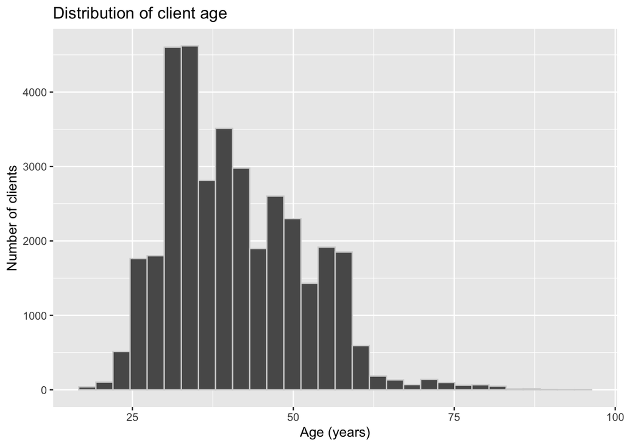

```r
ggplot(bank_demo_df, aes(x = age)) +
  geom_histogram(bins = 30, color = 'lightgrey') +
  labs(
    x = "Age (years)",
    y = "Number of clients",
    title = "Distribution of client age"
  )
```

Age is right-skewed, ranging from 18 to 95 with a median of 39.

```r
bank_demo_df |>
  group_by(is_deposit) |>
  summarise(
    mean = mean(age, na.rm = TRUE),
    sd = sd(age, na.rm = TRUE),
    min = min(age, na.rm = TRUE),
    q1 = quantile(age, 0.25, na.rm = TRUE),
    median = median(age, na.rm = TRUE),
    q3 = quantile(age, 0.75, na.rm = TRUE),
    max = max(age, na.rm = TRUE)
  ) |>
  kable(
    col.names = c("Subscribed", "Mean", "SD", "Min", "Q1", "Median", "Q3", "Max"),
    digits = c(0, 1, 1, 0, 0, 0, 0, 0),
    align = c("l", rep("r", 7))
  )
```

Table 5: Summary statistics for client age, by term deposit subscription.

| Subscribed | Mean | SD | Min | Q1 | Median | Q3 | Max |
| --- | --- | --- | --- | --- | --- | --- | --- |
| no | 40.9 | 10.1 | 18 | 33 | 39 | 48 | 95 |
| yes | 41.7 | 13.6 | 18 | 31 | 38 | 51 | 95 |

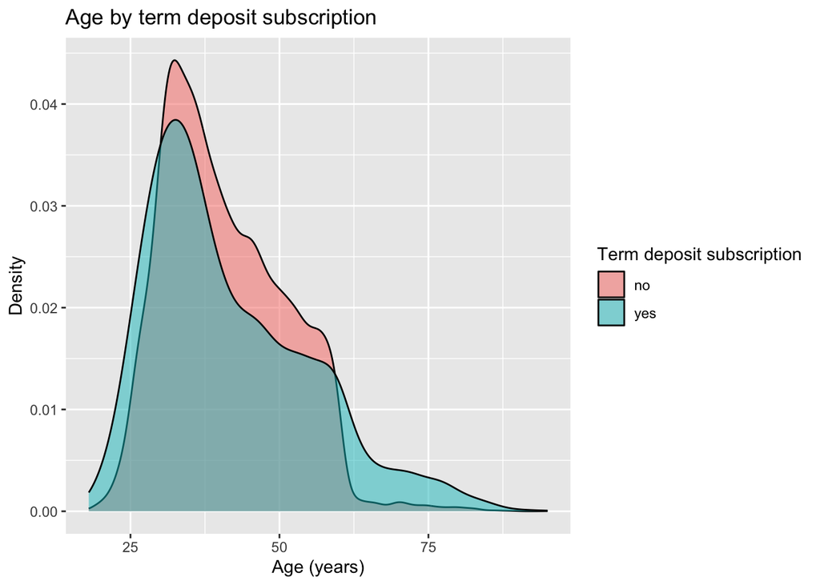

```r
ggplot(bank_demo_df, aes(x = age, fill = is_deposit)) +
  geom_density(alpha = 0.5) +
  labs(
    x = "Age (years)",
    y = "Density",
    fill = "Term deposit subscription",
    title = "Age by term deposit subscription"
  )
```

```r
bank_demo_df |>
  mutate(age_group = cut(
    age,
    breaks = c(17, 25, 35, 45, 55, 65, Inf),
    labels = c("18-25", "26-35", "36-45", "46-55", "56-65", "66+")
  )) |>
  group_by(age_group) |>
  summarise(
    n = n(),
    n_yes = sum(is_deposit == "yes"),
    perc_yes = round(n_yes / n * 100, 2)
  ) |>
  kable(
    col.names = c("Age group", "Clients", "Subscribed", "Subscription rate (%)"),
    format.args = list(big.mark = ","),
    align = c("l", "r", "r", "r")
  )
```

Table 6: Term deposit subscription rate by age group.

| Age group | Clients | Subscribed | Subscription rate (%) |
| --- | --- | --- | --- |
| 18-25 | 1,060 | 264 | 24.91 |
| 26-35 | 12,380 | 1,501 | 12.12 |
| 36-45 | 11,200 | 1,030 | 9.20 |
| 46-55 | 7,629 | 710 | 9.31 |
| 56-65 | 3,293 | 465 | 14.12 |
| 66+ | 606 | 261 | 43.07 |

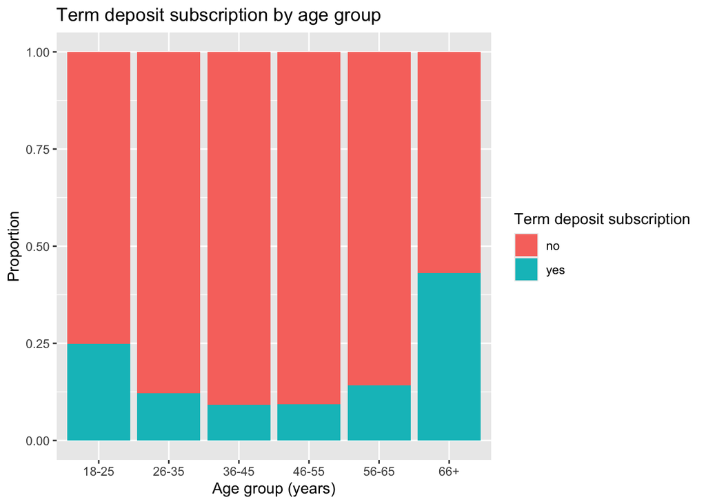

```r
bank_demo_df |>
  mutate(age_group = cut(
    age,
    breaks = c(17, 25, 35, 45, 55, 65, Inf),
    labels = c("18-25", "26-35", "36-45", "46-55", "56-65", "66+")
  )) |>
  ggplot(aes(x = age_group, fill = is_deposit)) +
  geom_bar(position = "fill") +
  labs(
    x = "Age group (years)",
    y = "Proportion",
    fill = "Term deposit subscription",
    title = "Term deposit subscription by age group"
  )
```

Subscription is U-shaped by age: about 25% for ages 25 or younger, 9% for ages 36-55, and 43% for ages over 65.

#### Marital status

```r
bank_demo_df |>
  group_by(marital) |>
  summarise(
    n = n(),
    n_yes = sum(is_deposit == "yes"),
    perc_yes = round(n_yes / n * 100, 2)
  ) |>
  mutate(perc = round(n / sum(n) * 100, 2), .after = n) |>
  arrange(desc(n)) |>
  kable(
    col.names = c("Marital status", "Clients", "Percent of clients (%)",
                  "Subscribed", "Subscription rate (%)"),
    format.args = list(big.mark = ","),
    align = c("l", rep("r", 4))
  )
```

Table 7: Marital status distribution and term deposit subscription rate.

| Marital status | Clients | Percent of clients (%) | Subscribed | Subscription rate (%) |
| --- | --- | --- | --- | --- |
| married | 21,718 | 60.05 | 2,191 | 10.09 |
| single | 10,271 | 28.40 | 1,534 | 14.94 |
| divorced | 4,179 | 11.55 | 506 | 12.11 |

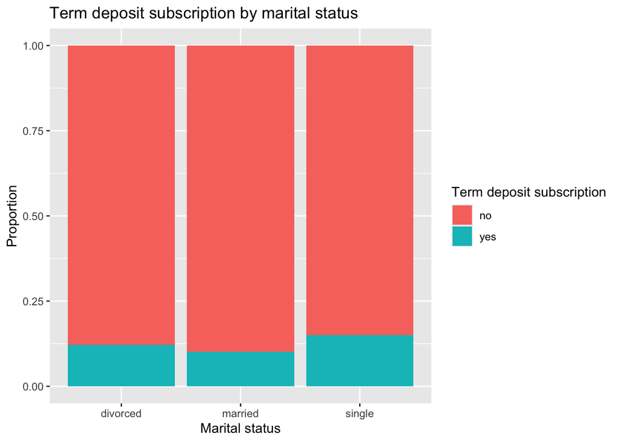

```r
ggplot(bank_demo_df, aes(x = marital, fill = is_deposit)) +
  geom_bar(position = "fill") +
  labs(
    x = "Marital status",
    y = "Proportion",
    fill = "Term deposit subscription",
    title = "Term deposit subscription by marital status"
  )
```

Most clients are married (60%). Single clients subscribed most (15%) and married least (10%).

#### Job

```r
bank_demo_df |>
  group_by(job) |>
  summarise(
    n = n(),
    n_yes = sum(is_deposit == "yes"),
    perc_yes = round(n_yes / n * 100, 2)
  ) |>
  mutate(perc = round(n / sum(n) * 100, 2), .after = n) |>
  arrange(desc(n)) |>
  kable(
    col.names = c("Job", "Clients", "Percent of clients (%)",
                  "Subscribed", "Subscription rate (%)"),
    format.args = list(big.mark = ","),
    align = c("l", rep("r", 4))
  )
```

Table 8: Job distribution and term deposit subscription rate.

| Job | Clients | Percent of clients (%) | Subscribed | Subscription rate (%) |
| --- | --- | --- | --- | --- |
| blue-collar | 7,799 | 21.56 | 565 | 7.24 |
| management | 7,454 | 20.61 | 1,019 | 13.67 |
| technician | 6,111 | 16.90 | 681 | 11.14 |
| admin. | 4,208 | 11.63 | 521 | 12.38 |
| services | 3,325 | 9.19 | 294 | 8.84 |
| retired | 1,809 | 5.00 | 418 | 23.11 |
| self-employed | 1,271 | 3.51 | 143 | 11.25 |
| entrepreneur | 1,192 | 3.30 | 95 | 7.97 |
| unemployed | 1,050 | 2.90 | 165 | 15.71 |
| housemaid | 965 | 2.67 | 83 | 8.60 |
| student | 756 | 2.09 | 222 | 29.37 |
| unknown | 228 | 0.63 | 25 | 10.96 |

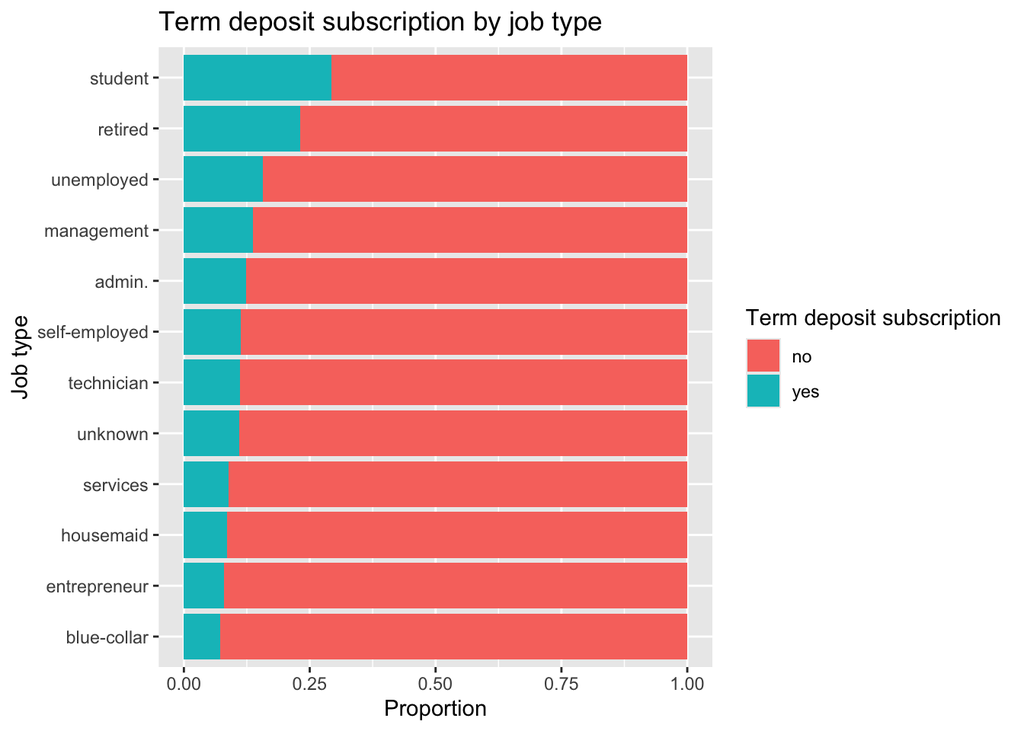

```r
#### Order jobs by subscription rate so the plot is easier to read
job_order <- bank_demo_df |>
  group_by(job) |>
  summarise(rate = mean(is_deposit == "yes")) |>
  arrange(rate) |>
  pull(job)

ggplot(bank_demo_df, aes(y = factor(job, levels = job_order), fill = is_deposit)) +
  geom_bar(position = "fill") +
  labs(
    x = "Proportion",
    y = "Job type",
    fill = "Term deposit subscription",
    title = "Term deposit subscription by job type"
  )
```

Students (29%) and retirees (23%) subscribed most; blue-collar workers (7%) least.

#### Education

```r
bank_demo_df |>
  group_by(education) |>
  summarise(
    n = n(),
    n_yes = sum(is_deposit == "yes"),
    perc_yes = round(n_yes / n * 100, 2)
  ) |>
  mutate(perc = round(n / sum(n) * 100, 2), .after = n) |>
  kable(
    col.names = c("Education", "Clients", "Percent of clients (%)",
                  "Subscribed", "Subscription rate (%)"),
    format.args = list(big.mark = ","),
    align = c("l", rep("r", 4))
  )
```

Table 9: Education distribution and term deposit subscription rate.

| Education | Clients | Percent of clients (%) | Subscribed | Subscription rate (%) |
| --- | --- | --- | --- | --- |
| primary | 5,462 | 15.10 | 468 | 8.57 |
| secondary | 18,638 | 51.53 | 1,975 | 10.60 |
| tertiary | 10,552 | 29.17 | 1,584 | 15.01 |
| unknown | 1,516 | 4.19 | 204 | 13.46 |

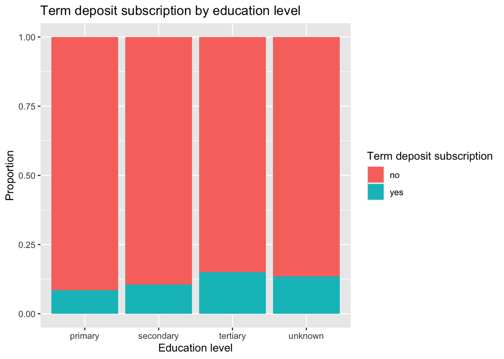

```r
ggplot(bank_demo_df,
       aes(x = factor(education, levels = c("primary", "secondary", "tertiary", "unknown")),
           fill = is_deposit)) +
  geom_bar(position = "fill") +
  labs(
    x = "Education level",
    y = "Proportion",
    fill = "Term deposit subscription",
    title = "Term deposit subscription by education level"
  )
```

Subscription rises with education: 9% (primary), 11% (secondary), 15% (tertiary).

### Financial health variables

```r
#### Filter the columns default, balance, housing, loan and the target columns of y
bank_fin_df <- bank_df |> select(default, balance, housing, loan, y) |>
  rename(is_deposit = y)

head(bank_fin_df)
```

```
# A tibble: 6 × 5
  default balance housing loan  is_deposit
  <chr>     <dbl> <chr>   <chr> <chr>
1 no         2143 yes     no    no
2 no           29 yes     no    no
3 no            2 yes     yes   no
4 no         1506 yes     no    no
5 no            1 no      no    no
6 no          231 yes     no    no
```

#### Credit default

```r
bank_fin_df |>
  group_by(default) |>
  summarise(
    n = n(),
    n_yes = sum(is_deposit == "yes"),
    perc_yes = round(n_yes / n * 100, 2)
  ) |>
  mutate(perc = round(n / sum(n) * 100, 2), .after = n) |>
  arrange(desc(n)) |>
  kable(
    col.names = c("Credit in default", "Clients", "Percent of clients (%)",
                  "Subscribed", "Subscription rate (%)"),
    format.args = list(big.mark = ","),
    align = c("l", rep("r", 4))
  )
```

Table 10: Credit default status and term deposit subscription rate.

| Credit in default | Clients | Percent of clients (%) | Subscribed | Subscription rate (%) |
| --- | --- | --- | --- | --- |
| no | 35,517 | 98.2 | 4,191 | 11.80 |
| yes | 651 | 1.8 | 40 | 6.14 |

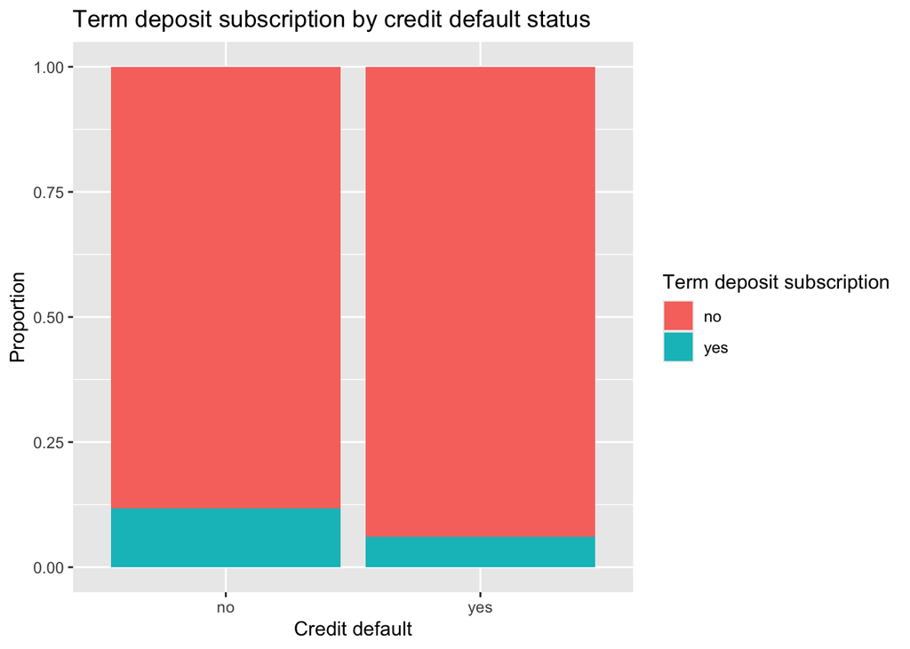

```r
ggplot(bank_fin_df, aes(x = default, fill = is_deposit)) +
  geom_bar(position = "fill") +
  labs(
    x = "Credit default",
    y = "Proportion",
    fill = "Term deposit subscription",
    title = "Term deposit subscription by credit default status"
  )
```

Under 2% of clients are in default; they subscribed at 6% vs 12% for others.

#### Housing loan

```r
bank_fin_df |>
  group_by(housing) |>
  summarise(
    n = n(),
    n_yes = sum(is_deposit == "yes"),
    perc_yes = round(n_yes / n * 100, 2)
  ) |>
  mutate(perc = round(n / sum(n) * 100, 2), .after = n) |>
  arrange(desc(n)) |>
  kable(
    col.names = c("Has housing loan", "Clients", "Percent of clients (%)",
                  "Subscribed", "Subscription rate (%)"),
    format.args = list(big.mark = ","),
    align = c("l", rep("r", 4))
  )
```

Table 11: Housing loan status and term deposit subscription rate.

| Has housing loan | Clients | Percent of clients (%) | Subscribed | Subscription rate (%) |
| --- | --- | --- | --- | --- |
| yes | 20,177 | 55.79 | 1,533 | 7.60 |
| no | 15,991 | 44.21 | 2,698 | 16.87 |

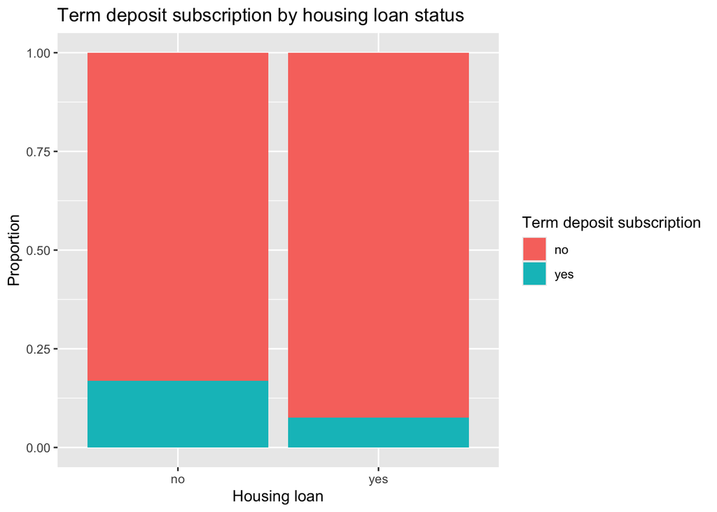

```r
ggplot(bank_fin_df, aes(x = housing, fill = is_deposit)) +
  geom_bar(position = "fill") +
  labs(
    x = "Housing loan",
    y = "Proportion",
    fill = "Term deposit subscription",
    title = "Term deposit subscription by housing loan status"
  )
```

Clients without a housing loan subscribed at 17%, over twice the rate of those with one (8%).

#### Personal loan

```r
bank_fin_df |>
  group_by(loan) |>
  summarise(
    n = n(),
    n_yes = sum(is_deposit == "yes"),
    perc_yes = round(n_yes / n * 100, 2)
  ) |>
  mutate(perc = round(n / sum(n) * 100, 2), .after = n) |>
  arrange(desc(n)) |>
  kable(
    col.names = c("Has personal loan", "Clients", "Percent of clients (%)",
                  "Subscribed", "Subscription rate (%)"),
    format.args = list(big.mark = ","),
    align = c("l", rep("r", 4))
  )
```

Table 12: Personal loan status and term deposit subscription rate.

| Has personal loan | Clients | Percent of clients (%) | Subscribed | Subscription rate (%) |
| --- | --- | --- | --- | --- |
| no | 30,468 | 84.24 | 3,833 | 12.58 |
| yes | 5,700 | 15.76 | 398 | 6.98 |

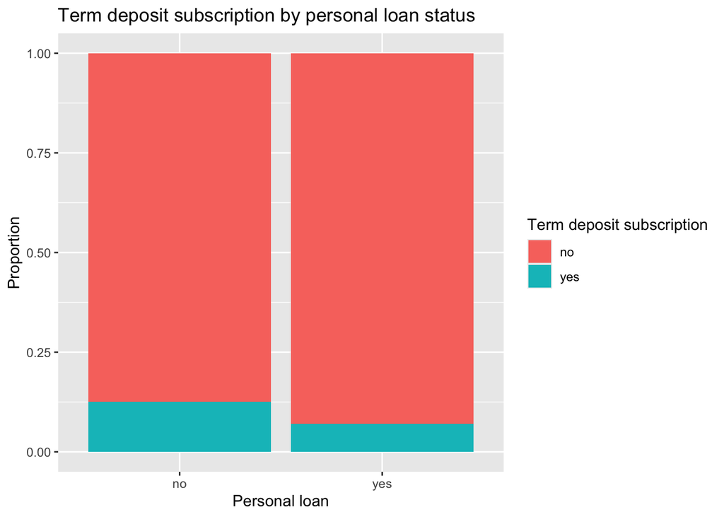

```r
ggplot(bank_fin_df, aes(x = loan, fill = is_deposit)) +
  geom_bar(position = "fill") +
  labs(
    x = "Personal loan",
    y = "Proportion",
    fill = "Term deposit subscription",
    title = "Term deposit subscription by personal loan status"
  )
```

Clients with a personal loan subscribed at 7% vs 13% for those without.

#### Combined loan burden

```r
bank_fin_df |>
  mutate(any_loan = if_else(housing == "yes" | loan == "yes", "Yes", "No")) |>
  group_by(any_loan) |>
  summarise(
    n = n(),
    n_yes = sum(is_deposit == "yes"),
    perc_yes = round(n_yes / n * 100, 2)
  ) |>
  mutate(perc = round(n / sum(n) * 100, 2), .after = n) |>
  arrange(desc(n)) |>
  kable(
    col.names = c("Has any loan", "Clients", "Percent of clients (%)",
                  "Subscribed", "Subscription rate (%)"),
    format.args = list(big.mark = ","),
    align = c("l", rep("r", 4))
  )
```

Table 13: Any loan (housing or personal) and term deposit subscription rate.

| Has any loan | Clients | Percent of clients (%) | Subscribed | Subscription rate (%) |
| --- | --- | --- | --- | --- |
| Yes | 22,448 | 62.07 | 1,715 | 7.64 |
| No | 13,720 | 37.93 | 2,516 | 18.34 |

```r
bank_fin_df |>
  mutate(loan_status = case_when(
    housing == "yes" & loan == "yes" ~ "Both loans",
    housing == "yes" ~ "Housing loan only",
    loan == "yes" ~ "Personal loan only",
    TRUE ~ "No loans"
  )) |>
  group_by(loan_status) |>
  summarise(
    n = n(),
    subscription_rate = round(mean(is_deposit == "yes") * 100, 2)
  ) |>
  arrange(desc(subscription_rate)) |>
  kable(
    col.names = c("Loan status", "Clients", "Subscription rate (%)"),
    format.args = list(big.mark = ","),
    align = c("l", "r", "r")
  )
```

Table 14: Term deposit subscription rate by combination of housing and personal loans.

| Loan status | Clients | Subscription rate (%) |
| --- | --- | --- |
| No loans | 13,720 | 18.34 |
| Personal loan only | 2,271 | 8.01 |
| Housing loan only | 16,748 | 7.86 |
| Both loans | 3,429 | 6.30 |

Clients with no loans subscribed at 18% vs 8% for those with at least one.

#### Account balance

```r
bank_fin_df |>
  summarise(
    mean = mean(balance, na.rm = TRUE),
    sd = sd(balance, na.rm = TRUE),
    min = min(balance, na.rm = TRUE),
    q1 = quantile(balance, 0.25, na.rm = TRUE),
    median = median(balance, na.rm = TRUE),
    q3 = quantile(balance, 0.75, na.rm = TRUE),
    max = max(balance, na.rm = TRUE),
    perc_negative = round(mean(balance < 0, na.rm = TRUE) * 100, 2)
  ) |>
  kable(
    col.names = c("Mean", "SD", "Min", "Q1", "Median", "Q3", "Max", "Negative (%)"),
    digits = c(1, 1, 0, 0, 0, 0, 0, 2),
    format.args = list(big.mark = ","),
    align = "r"
  )
```

Table 15: Summary statistics for client account balance.

| Mean | SD | Min | Q1 | Median | Q3 | Max | Negative (%) |
| --- | --- | --- | --- | --- | --- | --- | --- |
| 1,364.7 | 2,991.4 | -8,019 | 74 | 453 | 1,437 | 98,417 | 8.23 |

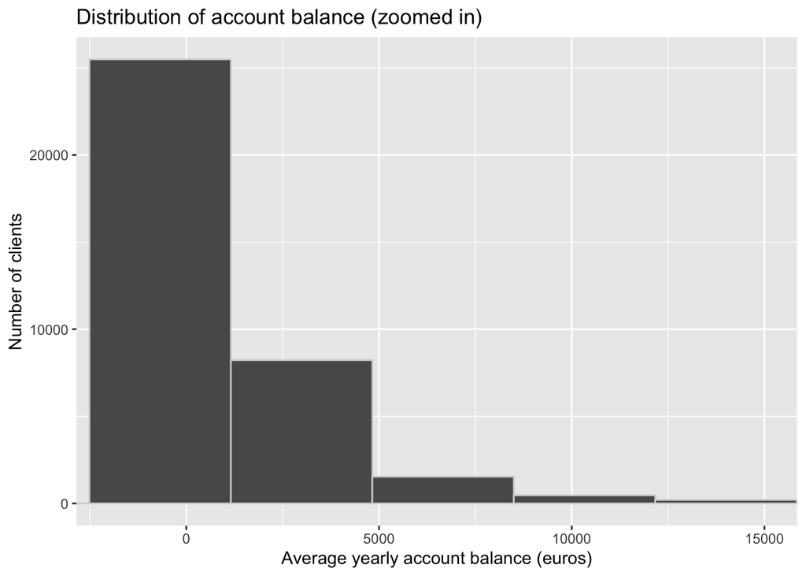

```r
ggplot(bank_fin_df, aes(x = balance)) +
  geom_histogram(bins = 30, color = 'lightgrey') +
  labs(
    x = "Average yearly account balance (euros)",
    y = "Number of clients",
    title = "Distribution of account balance (zoomed in)"
  ) +
  coord_cartesian(xlim = c(-2000, 15000))
```

Balance is strongly right-skewed (median 450, mean 1,370 euros), and 8% of clients are negative.

```r
bank_fin_df |>
  group_by(is_deposit) |>
  summarise(
    mean = mean(balance, na.rm = TRUE),
    sd = sd(balance, na.rm = TRUE),
    min = min(balance, na.rm = TRUE),
    q1 = quantile(balance, 0.25, na.rm = TRUE),
    median = median(balance, na.rm = TRUE),
    q3 = quantile(balance, 0.75, na.rm = TRUE),
    max = max(balance, na.rm = TRUE),
    perc_negative = round(mean(balance < 0, na.rm = TRUE) * 100, 2)
  ) |>
  kable(
    col.names = c("Subscribed", "Mean", "SD", "Min", "Q1", "Median", "Q3", "Max", "Negative (%)"),
    digits = c(0, 1, 1, 0, 0, 0, 0, 0, 2),
    format.args = list(big.mark = ","),
    align = c("l", rep("r", 8))
  )
```

Table 16: Summary statistics for client account balance, by term deposit subscription.

| Subscribed | Mean | SD | Min | Q1 | Median | Q3 | Max | Negative (%) |
| --- | --- | --- | --- | --- | --- | --- | --- | --- |
| no | 1,314.4 | 2,968.4 | -8,019 | 61 | 424 | 1,358 | 98,417 | 8.75 |
| yes | 1,744.7 | 3,134.0 | -1,944 | 206 | 710 | 2,094 | 81,204 | 4.33 |

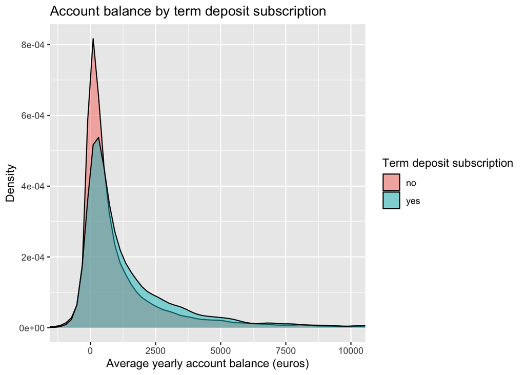

```r
ggplot(bank_fin_df, aes(x = balance, fill = is_deposit)) +
  geom_density(alpha = 0.5) +
  labs(
    x = "Average yearly account balance (euros)",
    y = "Density",
    fill = "Term deposit subscription",
    title = "Account balance by term deposit subscription"
  ) +
  coord_cartesian(xlim = c(-1000, 10000))
```

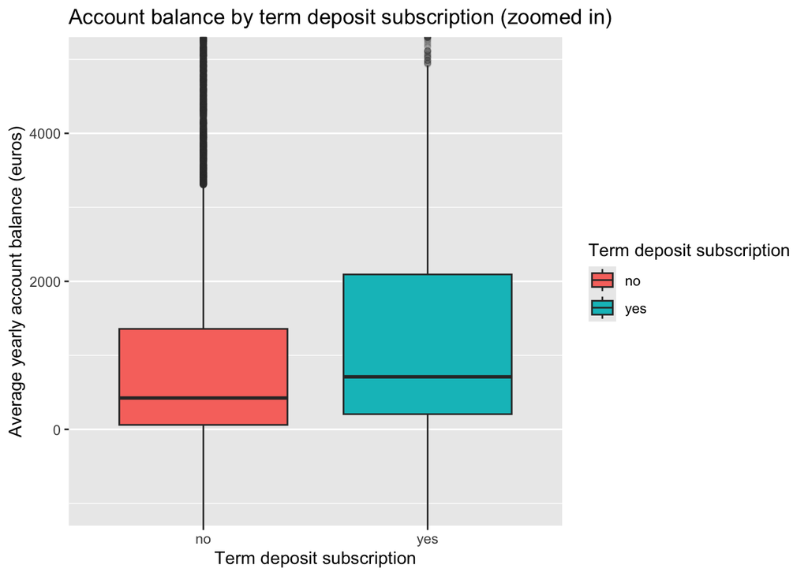

```r
ggplot(bank_fin_df, aes(x = is_deposit, y = balance, fill = is_deposit)) +
  geom_boxplot(outlier.alpha = 0.1) +
  labs(
    x = "Term deposit subscription",
    y = "Average yearly account balance (euros)",
    fill = "Term deposit subscription",
    title = "Account balance by term deposit subscription (zoomed in)"
  ) +
  coord_cartesian(ylim = c(-1000, 5000))
```

Subscribers have a higher median balance (710 vs 420 euros), but the distributions overlap heavily.

```r
bank_fin_df |>
  group_by(default) |>
  summarise(
    median_balance = median(balance, na.rm = TRUE),
    mean_balance = mean(balance, na.rm = TRUE)
  ) |>
  kable(
    col.names = c("Credit in default", "Median balance", "Mean balance"),
    digits = c(0, 0, 1),
    format.args = list(big.mark = ","),
    align = c("l", "r", "r")
  )
```

Table 17: Median and mean account balance by credit default status.

| Credit in default | Median balance | Mean balance |
| --- | --- | --- |
| no | 472 | 1,392.2 |
| yes | -5 | -134.6 |

Clients in default have a median balance of -5 euros, so credit default and account balance overlap.

### Summary of exploratory findings

Among the demographic variables, age and job showed the largest differences in subscription rate. Subscription followed a U-shaped pattern by age, being highest for the youngest and oldest clients, while education and marital status showed smaller differences. Among the financial health variables, having a housing loan, a personal loan or a credit default was associated with lower subscription, and a higher account balance was associated with slightly higher subscription. Because the target is imbalanced, with about 12% of clients subscribing, we evaluated models using F1 instead of accuracy. We also want to balance out recall and precision as both false positives and negatives are harmful to the banks profits and resources.

## Preprocessing

We used nine predictors available before the current marketing call: age, marital status, occupation, education, credit default, average yearly account balance, housing loan status, personal loan status, and the outcome of the previous marketing campaign. We kept the existing training and test split and treated subscription as the positive class.

We converted categorical predictors to indicator variables and standardized age and account balance. During cross-validation, we estimated these transformations using only the training portion of each fold and applied them to that fold’s validation data. For the final evaluation, we estimated the transformations on the full training set and applied them to the test set.

## Training-set evaluation

We chose to use a classification model using a Logistic Regression with all nine predictors. To predict whether a client would accept the term deposit, We compared ten classification thresholds using stratified five-fold cross-validation and checked across a range of possible thresholds below 0.5 due to the heavily imbalanced classes in our dataset. We found that a threshold of 0.15 was optimal among the thresholds tested due to having the highest mean F1 score. Because the threshold was selected using only training-data folds, the test set gives an unbiased estimate of performance.

Table 18 compares the mean F1, precision, recall, and accuracy across the five cross-validation folds for each candidate threshold.

Table 18: Mean cross-validation scores for the ten candidate classification thresholds, ranked by F1.

| Threshold | F1 (%) | Precision (%) | Recall (%) | Accuracy (%) |
| --- | --- | --- | --- | --- |
| 0.15 | 35.86 | 29.57 | 45.62 | 80.92 |
| 0.20 | 35.64 | 42.82 | 30.54 | 87.11 |
| 0.25 | 31.87 | 51.46 | 23.09 | 88.46 |
| 0.30 | 30.10 | 57.91 | 20.35 | 88.95 |
| 0.10 | 29.97 | 19.22 | 68.05 | 62.80 |
| 0.35 | 29.06 | 62.35 | 18.96 | 89.18 |
| 0.40 | 28.09 | 64.20 | 17.99 | 89.23 |
| 0.45 | 26.31 | 65.08 | 16.50 | 89.20 |
| 0.50 | 24.83 | 65.64 | 15.32 | 89.16 |
| 0.05 | 22.65 | 12.89 | 93.17 | 25.57 |

## Test-set evaluation

We refitted the logistic regression model on the full training set and evaluated it on the original test set. We classified clients as predicted subscribers when their estimated probability was at least 0.15. We report accuracy for overall classification performance, precision for the share of predicted subscribers who actually subscribed, and recall for the share of actual subscribers the model identified. The F1 score summarizes precision and recall.

```r
# Test data evaluation
test_data <- read_csv("../data/processed/bank_test.csv")
# Predict on test data
logistic_fit <- fit(pipe_logistic, data = training_data)

# Adjust the threshold to 0.15
logistic_prob <- predict(logistic_fit, test_data, type = "prob")$.pred_yes
actual_yes <- test_data$y == "yes"
logistic_yes <- logistic_prob >= 0.15

accuracy = mean(logistic_yes == actual_yes)
precision = mean(actual_yes[logistic_yes])
recall = mean(logistic_yes[actual_yes])

# Calculate F1 and other metric scores
scores <- rbind(
  "Logistic regression" = c(
    accuracy = accuracy,
    precision = precision,
    recall = recall,
    f1 = 2 * precision * recall / (precision + recall)
  )
)
```

Table 19 summarizes the test-set accuracy, precision, recall, and F1 score at the 0.15 classification threshold.

Table 19: Test-set accuracy, precision, recall, and F1 for logistic regression at the 0.15 classification threshold.

| Model | F1 | Precision | Recall | Accuracy |
| --- | --- | --- | --- | --- |
| Logistic regression | 35.07% | 28.89% | 44.61% | 80.67% |

```r
test_preds_class <- tibble(
  y = factor(test_data$y, levels = c("yes", "no")),
  .pred_class = factor(if_else(logistic_prob >= 0.15, "yes", "no"),
                       levels = c("yes", "no"))
)

cm_test <- conf_mat(test_preds_class, truth = y, estimate = .pred_class)
cm_test
```

```
          Truth
Prediction  yes   no
       yes  472 1162
       no   586 6823
```

```r
#autoplot(cm_test, type = "heatmap")
```

While there is promise in this model as a tool to build a more targeted call list to match clients with term deposits, it still requires more work. The logistic regression model did show that information available before a marketing call can help identify clients who are likely to subscribe to a term deposit. However, even using a threshold of 0.15 to maximize the F1 score, recall was only 44.61%, meaning the model still missed 55.39% of the clients who would have invested in term deposits. While tuning on a slightly finer grid may help to improve our score metrics, it is likely our predictor variables may not be carrying a strong enough signal. Logistic regression assumes that age and account balance have linear relationships with the log-odds of subscription and that predictor effects are additive on the log-odds scale. These assumptions may miss nonlinear patterns or interactions among client characteristics.

A follow-up study could evaluate the model on a later campaign and ask how many subscribers it identifies when the bank can contact only a fixed number of clients.

# Results

As shown in Figure 1, logistic regression achieved 80.67% accuracy and an F1 score of 35.07% on the test set at the 0.15 classification threshold. The model identified 472 of the 1,058 clients who subscribed, yielding a recall of 44.61%. Of the 1,634 clients predicted to subscribe, 472 actually did, yielding a precision of 28.89%.

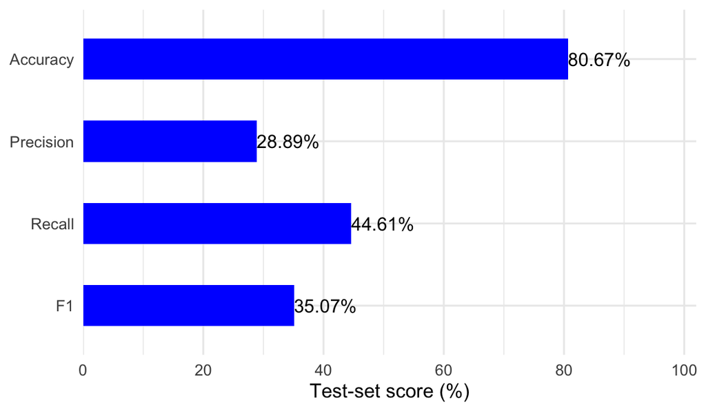

Figure 1: Test-set accuracy, precision, recall, and F1 for logistic regression at the 0.15 classification threshold.

The confusion matrix in Figure 2 shows how the errors were distributed. The model missed 586 actual subscribers and incorrectly predicted subscription for 1,162 non-subscribers. It correctly classified 6,823 of the 7,985 non-subscribers. Overall, the model correctly identified a substantially larger share of non-subscribers than subscribers.

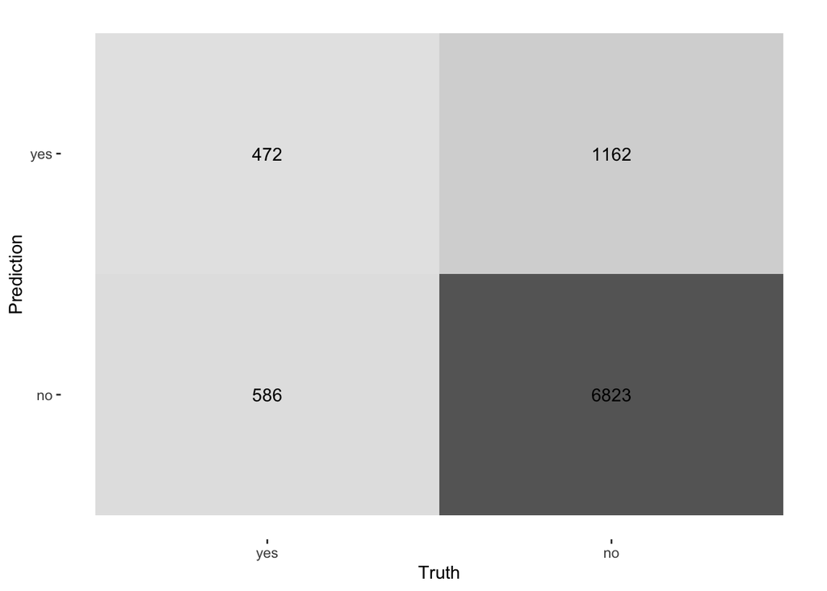

Figure 2: Test-set confusion matrix for logistic regression at the 0.15 classification threshold. Rows show predicted outcomes and columns show actual outcomes.

At the 0.15 threshold, the model flagged 1,634 of the 9,043 test-set clients (18.1%). This group contained 44.6% of all actual subscribers. The observed subscription rate among flagged clients was 28.89%, about 2.5 times the overall test-set rate of 11.70%. Thus, actual subscribers were more concentrated in the group flagged by the model.

Our results suggest that information available before a marketing call can help identify clients who are likely to subscribe to a term deposit. At the classification threshold of 0.15, logistic regression achieved an F1 score of 35.07%, with 28.89% precision, 44.61% recall, and 80.67% accuracy on the test set. The model identified 472 of the 1,058 actual subscribers and missed 586. We expected accuracy to give an incomplete picture because most clients did not subscribe. Recall shows how many subscribers the model found, while precision shows how many clients on its proposed call list ultimately subscribed.

The model flagged 1,634 clients for outreach, which 1,162 of them did not subscribe. In practical terms, about 29 out of every 100 clients on the proposed list subscribed. This illustrates the decision the bank faces. A longer call list may reach more potential subscribers, but it also takes more time and increases the number of calls to clients who do not subscribe. The value of the model therefore depends on the bank’s call budget and the value of reaching additional subscribers.

Prasad et al. (2025) compared several classifiers for the same prediction task. Their blending model had the highest reported accuracy in their comparison (90.5%), with 74.59% precision and 23.62% recall. Our logistic regression had higher observed recall and lower observed precision. These figures provide context for the different priorities a bank might have when building a call list. The studies used different data and predictors, so a direct model comparison would require evaluating both approaches on the same test set with the same pre-call information.

Logistic regression assumes that the effects of predictors are additive on the log-odds scale and that age and account balance enter as linear terms on that scale. This may limit its ability to capture patterns such as the U-shaped relationship between age and subscription rate observed in the training data. We also evaluated the model on a single test split, so performance may differ in later campaigns. Overall, logistic regression provides a starting point for prioritizing outreach, although it still misses more than half of actual subscribers. A follow-up study could compare logistic regression with a model on a later campaign and measure how many subscribers each model identifies under the same call budget.

# References

Kuhn, M., & Wickham, H. (2020). *Tidymodels: A collection of packages for modeling and machine learning using tidyverse principles* [Computer software]. https://www.tidymodels.org

Moro, S., Cortez, P., & Rita, P. (2014). A data-driven approach to predict the success of bank telemarketing. *Decision Support Systems, 62*, 22–31. https://doi.org/10.1016/j.dss.2014.03.001

Moro, S., Laureano, R., & Cortez, P. (2011). Using data mining for bank direct marketing: An application of the CRISP-DM methodology. In P. Novais et al. (Eds.), *Proceedings of the European Simulation and Modelling Conference (ESM’2011)* (pp. 117–121). EUROSIS. http://hdl.handle.net/1822/14838

Moro, S., Rita, P., & Cortez, P. (2014). *Bank marketing* [Data set]. UCI Machine Learning Repository. https://doi.org/10.24432/C5K306

Prasad, R., Choubey, M., Baghel, R. K., & Naruka, A. (2025). *Term deposit customer prediction: A blending approach using bank marketing data.* 2025 IEEE International Students’ Conference on Electrical, Electronics and Computer Science (SCEECS). https://doi.org/10.1109/SCEECS64059.2025.10940622

R Core Team. (2026). *R: A language and environment for statistical computing* (Version 4.6.1) [Computer software]. R Foundation for Statistical Computing. https://www.R-project.org/

Wickham, H., Averick, M., Bryan, J., Chang, W., McGowan, L. D., François, R., Grolemund, G., Hayes, A., Henry, L., Hester, J., Kuhn, M., Pedersen, T. L., Miller, E., Bache, S. M., Müller, K., Ooms, J., Robinson, D., Seidel, D. P., Spinu, V., … Yutani, H. (2019). Welcome to the tidyverse. *Journal of Open Source Software, 4*(43), 1686. https://doi.org/10.21105/joss.01686